# 2. The Copula Recursive Tree

2020-03-31

# Introduction

In this vignette, we will use the Cort algorithm to fit a copula on a given simulated dataset based on clayton copula simulations. We will show how the algorithm can be used to produce a bona-fide copula, and describe some of the parameters.

# Dataset

First, let’s create and plot the dataset we will work with. For that, we’ll use the gamma frailty model for the Clayton copula (but it’ll work for any other completely monotonous archimedean generator), as it is done in the `copula` package, see [there](https://github.com/cran/copula/blob/6e0a5f0332776c24b2f53a81b11a8c66cc3f996d/R/claytonCopula.R#L82). The following code is directly taken from the previous link, from the `copula` package :

```r
psi <- function(t,alpha) (1 + sign(alpha)*t) ^ (-1/alpha) # generator
rClayton <- function(n,dim,alpha){
  val <- matrix(runif(n * dim), nrow = n)
  gam <- rgamma(n, shape = 1/alpha, rate = 1)
  gam <- matrix(gam, nrow = n, ncol = dim)
  psi(- log(val) / gam,alpha)
}
```

For reproducibility reasons, we set the random number generator. This vignette has been compiled on a version of R > 3.6, so the fix of the random number generator added in this version is used. To reproduce results from an earlier version, just use `sample.kind = "Rounding"`. The following code simulates a dataset and then visualise it :

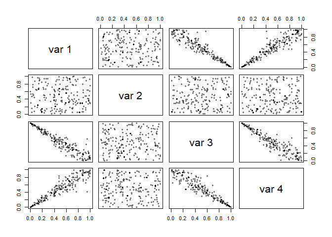

```r
if(as.numeric(version$minor)<6){
  # the way of specifying the random number generation changed.
  set.seed(12,kind = "Mersenne-Twister",normal.kind = "Inversion")
} else {
  set.seed(12,kind = "Mersenne-Twister",normal.kind = "Inversion",sample.kind = "Rejection")
}


n = 200 # taken small to reduce runtime of the vignette.
d = 4
n_trees = 5 # taken small to reduce runtime of the vignette.
number_max_dim_forest = 2 # taken small to reduce runtime of the vignette.

data <- matrix(nrow=n,ncol=d)
data[,c(1,4,3)] = rClayton(n=n,dim=d-1,alpha=7)
data[,2] = runif(n)
data[,3] <- 1 - data[,3]


pairs(data,cex=0.6)
```

We can clearly see that the second marginal is independent form the rest. In the following we will use this package to fit this dependence structure.

# Fitting the Cort copula

Now that we have a dataset, we can run the Cort algorithm on it. In the implementation proposed here, this is done via the `cort::Cort()` function, passing first the dataset, and then various parameters. See `?Cort` for a detailed list of parameters. Note that the verbosity level is quite progressive: We will here put it on 4 to see the splitting decisions that the algorithm is making.

```r
(model = Cort(data,verbose_lvl=4,p_value_for_dim_red = 0.75))
```

```
#> Splitting...
#>
#>      1 leaves to split...
#>         Leaf with 200 points.
#>                     min   max   bp            p_value      action     reason
#>                 1   0     1     0.793066313   0.00000000   Splitted
#>                 2   0     1     0.073362799   0.74574575   Splitted
#>                 3   0     1     0.208957488   0.00000000   Splitted
#>                 4   0     1     0.789018711   0.00000000   Splitted
#>
#>
#>      10 leaves to split...
#>         Leaf with 10 points.
#>                     min          max           bp            p_value      action    reason
#>                 1   0.00000000   0.793066313   0.029266960   0.23323323   Removed   Close to boundary
#>                 2   0.00000000   0.073362799   0.024694101   1.00000000   Removed   Independence test
#>                 3   0.20895749   1.000000000   0.976639186   1.00000000   Removed   Independence test
#>                 4   0.00000000   0.789018711   0.024931546   1.00000000   Removed   Independence test
#>
#>         Leaf with 5 points.
#>                     min           max          bp           p_value       action    reason
#>                 1   0.000000000   0.79306631   0.74647612   0.025025025   Removed   Close to boundary
#>                 2   0.073362799   1.00000000   0.46782571   0.815815816   Removed   Independence test
#>                 3   0.000000000   0.20895749   0.11341065   1.000000000   Removed   Independence test
#>                 4   0.000000000   0.78901871   0.73903510   0.001001001   Removed   Close to boundary
#>
#>         Leaf with 2 points.
#>                     min           max          bp           p_value       action    reason
#>                 1   0.000000000   0.79306631   0.74622987   0.059059059   Removed   Close to boundary
#>                 2   0.073362799   1.00000000   0.74698467   1.000000000   Removed   Independence test
#>                 3   0.000000000   0.20895749   0.11288653   1.000000000   Removed   Independence test
#>                 4   0.789018711   1.00000000   0.95782035   1.000000000   Removed   Independence test
#>
#>         Leaf with 132 points.
#>                     min           max          bp            p_value      action     reason
#>                 1   0.000000000   0.79306631   0.042821551   0.00000000   Splitted
#>                 2   0.073362799   1.00000000   0.537607355   0.93793794   Removed    Independence test
#>                 3   0.208957488   1.00000000   0.956730821   0.00000000   Splitted
#>                 4   0.000000000   0.78901871   0.042245292   0.00000000   Splitted
#>
```

[output cut: 463 more lines]

```
#>    1  -8.7153e+01   2.85e-02   3.07e+04   1.00e-01   5.07e-03s
#>  200  -7.6454e+01   1.54e-04   2.74e-01   1.54e+00   2.37e-02s
#>  400  -7.6354e+01   6.17e-06   1.11e+00   4.61e+00   4.76e-02s
#>  450  -7.6346e+01   1.20e-07   8.57e-03   4.61e+00   5.18e-02s
#> plsh  -7.6346e+01   5.24e-16   2.74e-12  ---------   6.76e-02s
#>
#> status:               solved
#> solution polish:      successful
#> number of iterations: 450
#> optimal objective:    -76.3461
#> run time:             6.76e-02s
#> optimal rho estimate: 9.95e-01
#>
#> Done !
#> Cort copula model: 200x4-dataset and 152 leaves.
```

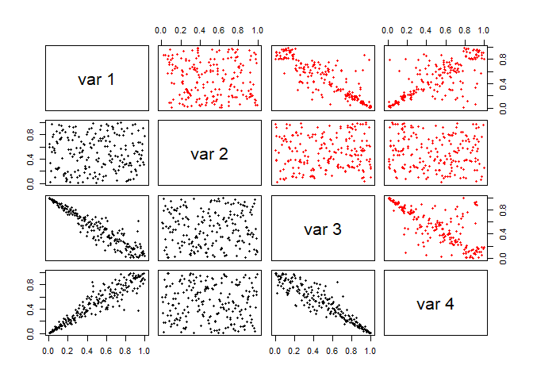

Pairs-plot of original data (in black, bottom-left corner) versus a simulation from the model (in red, top-right corner)

```r
pairs(model)
```

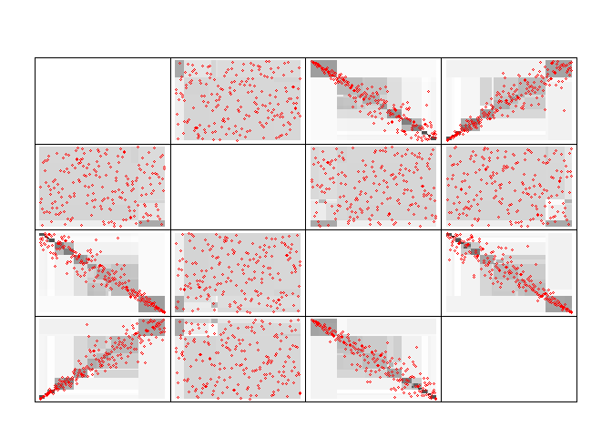

Gray boxes representing 2-d projections of the fitted density. In red, the imputed data points.

```r
plot(model)
```

We see that there are some noise with point were there should not be. A bagged version of the model is accessible via the `CortForest` class, and might be able to correct these problems.